# NYC_schools_perceptions

Bena

2023-05-19

# Setting up

```r
library(tidyverse)
```

# Import files

The data was downloaded from data.world & NYC education websites using the links below: https://data.world/dataquest/nyc-schools-data/workspace/file?filename=combined.csv & https://data.cityofnewyork.us/Education/2011-NYC-School-Survey/mnz3-dyi8

```r
nyc_hs <- read_csv("combined.csv")
survey_gened <- read_tsv("masterfile11_gened_final.txt")
survey_d75 <- read_tsv("masterfile11_d75_final.txt")
```

# Get overview of data

```r
head(nyc_hs)
```

```
## # A tibble: 6 × 30
##   DBN    schoo…¹ Num o…² SAT C…³ SAT M…⁴ SAT W…⁵ avg_s…⁶ AP Te…⁷ Total…⁸ Numbe…⁹
##   <chr>  <chr>     <dbl>   <dbl>   <dbl>   <dbl>   <dbl>   <dbl>   <dbl>   <dbl>
## 1 01M292 HENRY …      29     355     404     363    1122     2.5      NA      NA
## 2 01M448 UNIVER…      91     383     423     366    1172    39        49      10
## 3 01M450 EAST S…      70     377     402     370    1149    19        21      NA
## 4 01M458 FORSYT…       7     414     401     359    1174     2.5      NA      NA
## 5 01M509 MARTA …      44     390     433     384    1207     2.5      NA      NA
## 6 01M515 LOWER …     112     332     557     316    1205    24        26      24
## # … with 20 more variables: exams_per_student <dbl>, high_score_percent <dbl>,
## #   avg_class_size <dbl>, frl_percent <dbl>, total_enrollment <dbl>,
## #   ell_percent <dbl>, sped_percent <dbl>, selfcontained_num <dbl>,
## #   asian_per <dbl>, black_per <dbl>, hispanic_per <dbl>, white_per <dbl>,
## #   male_per <dbl>, female_per <dbl>, `Total Cohort` <dbl>,
## #   grads_percent <dbl>, dropout_percent <dbl>, boro <chr>, lat <dbl>,
## #   long <dbl>, and abbreviated variable names ¹school_name, …
```

```r
head(survey_gened)
```

```
## # A tibble: 6 × 1,942
##   dbn    bn    schoolname    d75 stude…¹ highs…² schoo…³  rr_s  rr_t  rr_p   N_s
##   <chr>  <chr> <chr>       <dbl> <chr>     <dbl> <chr>   <dbl> <dbl> <dbl> <dbl>
## 1 01M015 M015  P.S. 015 R…     0 No            0 Elemen…    NA    88    60    NA
## 2 01M019 M019  P.S. 019 A…     0 No            0 Elemen…    NA   100    60    NA
## 3 01M020 M020  P.S. 020 A…     0 No            0 Elemen…    NA    88    73    NA
## 4 01M034 M034  P.S. 034 F…     0 Yes           0 Elemen…    89    73    50   145
## 5 01M063 M063  P.S. 063 W…     0 No            0 Elemen…    NA   100    60    NA
## 6 01M064 M064  P.S. 064 R…     0 No            0 Elemen…    NA    94    61    NA
## # … with 1,931 more variables: N_t <dbl>, N_p <dbl>, nr_s <dbl>, nr_t <dbl>,
## #   nr_p <dbl>, saf_p_11 <dbl>, com_p_11 <dbl>, eng_p_11 <dbl>, aca_p_11 <dbl>,
## #   saf_t_11 <dbl>, com_t_11 <dbl>, eng_t_11 <dbl>, aca_t_11 <dbl>,
## #   saf_s_11 <dbl>, com_s_11 <dbl>, eng_s_11 <dbl>, aca_s_11 <dbl>,
## #   saf_tot_11 <dbl>, com_tot_11 <dbl>, eng_tot_11 <dbl>, aca_tot_11 <dbl>,
## #   p_q2h <dbl>, p_q7a <dbl>, p_q7b <dbl>, p_q7c <dbl>, p_q7d <dbl>,
## #   p_q8a <dbl>, p_q8b <dbl>, p_q8c <dbl>, p_q8d <dbl>, p_q8e <dbl>, …
```

```r
head(survey_d75)
```

```
## # A tibble: 6 × 1,773
##   dbn    bn    schoolname   d75 studen…¹ highs…² schoo…³  rr_s  rr_t  rr_p   N_s
##   <chr>  <chr> <chr>      <dbl> <chr>      <dbl> <chr>   <dbl> <dbl> <dbl> <dbl>
## 1 75K004 K004  P.S. K004      1 Yes            0 Distri…    38    90    72     8
## 2 75K036 K036  P.S. 36        1 Yes           NA Distri…    70    69    44    97
## 3 75K053 K053  P.S. K053      1 Yes           NA Distri…    94    97    53   131
## 4 75K077 K077  P.S. K077      1 Yes           NA Distri…    95    65    55    70
## 5 75K140 K140  P.S. K140      1 Yes            0 Distri…    77    70    42    69
## 6 75K141 K141  P.S. K141      1 Yes           NA Distri…    73    55    29    53
## # … with 1,762 more variables: N_t <dbl>, N_p <dbl>, nr_s <dbl>, nr_t <dbl>,
## #   nr_p <dbl>, saf_p_11 <dbl>, com_p_11 <dbl>, eng_p_11 <dbl>, aca_p_11 <dbl>,
## #   saf_t_11 <dbl>, com_t_11 <dbl>, eng_t_11 <dbl>, aca_t_11 <dbl>,
## #   saf_s_11 <dbl>, com_s_11 <dbl>, eng_s_11 <dbl>, aca_s_11 <dbl>,
## #   saf_tot_11 <dbl>, com_tot_11 <dbl>, eng_tot_11 <dbl>, aca_tot_11 <dbl>,
## #   p_q1c <dbl>, p_q10a <dbl>, p_q10b <dbl>, p_q10c <dbl>, p_q10d <dbl>,
## #   p_q10e <dbl>, p_q10f <dbl>, p_q11a <dbl>, p_q11b <dbl>, p_q11c <dbl>, …
```

```r
dim(nyc_hs)
```

```
## [1] 479  30
```

NYC High School data has 479 rows & 30 columns

```r
dim(survey_gened)
```

```
## [1] 1646 1942
```

general education survey data has 1646 rows & 1942 columns

```r
dim(survey_d75)
```

```
## [1]   56 1773
```

district75 survey data has 56 rows & 1773 columns

# A closer look at the data

What are the school categories?

```r
schooltype_gened <- survey_gened %>%
  pull(schooltype) %>%
  unique

print(schooltype_gened)
```

```
## [1] "Elementary School"                 "Elementary / Middle School"
## [3] "Middle / High School"              "Middle School"
## [5] "High School"                       "Elementary / Middle / High School"
## [7] "Early Childhood School"            "YABC"
```

```r
schooltype_d75 <- survey_d75 %>%
  pull(schooltype) %>%
  unique

print(schooltype_d75)
```

```
## [1] "District 75 Special Education"
```

School type in d75 data is “District 75 Special Education, which may refer to either high schools or elementary schools.

Since nyc_hs only contains data for NYC high schools, we’ll filter the school type for schooltype_gen We’ll also remove some columns & remain with those that are necessary to do the analysis. The removed columns show responses to each of the survey questions.

```r
survey_gened_select <- survey_gened %>%
  filter(schooltype == "High School") %>%
  select(dbn:aca_tot_11)

View(survey_gened_select)
```

```r
survey_d75_select <- survey_d75 %>%
  select(dbn:aca_tot_11)

View(survey_d75_select)
```

Remove the `bn` column since it’s contained in `dbn` variable

```r
survey_gened_select <- survey_gened_select %>%
  select(-bn)

survey_d75_select <- survey_d75_select %>%
  select(-bn)
```

# Combine the 2 dataframes for surveys

```r
survey_combined <- bind_rows(survey_gened_select, survey_d75_select)

View(survey_combined)
```

Alternatively

```r
survey_combined <- survey_gened_select %>%
  bind_rows(survey_d75_select)
```

Since we’re interested in relationships of survey_combined data with variables in the nyc_hs dataframe, it makes sense to join the survey data to nyc_hs using left_join(). This will retain only observations in the survey dataframe that correspond to observations in nyc_hs. Before joining, rename `dbn` so it matches `DBN` in nyc_hs

```r
survey_combined <- survey_combined %>%
  rename(DBN = "dbn")
```

```r
survey_nychs <- nyc_hs %>%
  left_join(survey_combined, by = "DBN")

View(survey_nychs)
```

# Establish which correlations may be interesting to explore further

```r
correlation_matrix <- survey_nychs %>%
  select(avg_sat_score, saf_p_11:aca_tot_11) %>%
  cor(use = "pairwise.complete.obs")

print(correlation_matrix)
```

```
##               avg_sat_score   saf_p_11   com_p_11  eng_p_11    aca_p_11
## avg_sat_score   1.000000000 0.08913424 -0.1139639 0.0094307 0.008276863
## saf_p_11        0.089134237 1.00000000  0.8029932 0.7984741 0.817219807
## com_p_11       -0.113963937 0.80299315  1.0000000 0.9291268 0.925565838
## eng_p_11        0.009430700 0.79847408  0.9291268 1.0000000 0.907884041
## aca_p_11        0.008276863 0.81721981  0.9255658 0.9078840 1.000000000
## saf_t_11        0.309144422 0.49046519  0.3149366 0.3392305 0.415400554
## com_t_11        0.107470334 0.23164622  0.2411942 0.2675333 0.285824766
## eng_t_11        0.056125707 0.31403333  0.3071861 0.3296697 0.373418577
## aca_t_11        0.141157527 0.36423106  0.3470251 0.3585188 0.419085881
## saf_s_11        0.277268115 0.73241477  0.5411576 0.5390565 0.593038790
## com_s_11        0.162302236 0.61691582  0.5687691 0.5450478 0.598092320
## eng_s_11        0.170346019 0.64749568  0.5913392 0.6075781 0.622737241
## aca_s_11        0.292587986 0.69197352  0.6146925 0.6236426 0.679837302
## saf_tot_11      0.276041045 0.82764669  0.6105585 0.6209748 0.682848168
## com_tot_11      0.089098561 0.64231997  0.6933924 0.6820356 0.711988528
## eng_tot_11      0.094794066 0.66370163  0.6714581 0.7101096 0.720034872
## aca_tot_11      0.173800408 0.70043795  0.7028261 0.7054661 0.789215088
##                saf_t_11  com_t_11   eng_t_11  aca_t_11  saf_s_11  com_s_11
## avg_sat_score 0.3091444 0.1074703 0.05612571 0.1411575 0.2772681 0.1623022
## saf_p_11      0.4904652 0.2316462 0.31403333 0.3642311 0.7324148 0.6169158
## com_p_11      0.3149366 0.2411942 0.30718612 0.3470251 0.5411576 0.5687691
## eng_p_11      0.3392305 0.2675333 0.32966966 0.3585188 0.5390565 0.5450478
## aca_p_11      0.4154006 0.2858248 0.37341858 0.4190859 0.5930388 0.5980923
## saf_t_11      1.0000000 0.7437526 0.79946285 0.8448628 0.5922487 0.3825288
## com_t_11      0.7437526 1.0000000 0.90329649 0.8960927 0.2527900 0.1683019
## eng_t_11      0.7994629 0.9032965 1.00000000 0.9498147 0.3678941 0.2887301
## aca_t_11      0.8448628 0.8960927 0.94981468 1.0000000 0.4186507 0.3239221
## saf_s_11      0.5922487 0.2527900 0.36789407 0.4186507 1.0000000 0.8227886
## com_s_11      0.3825288 0.1683019 0.28873011 0.3239221 0.8227886 1.0000000
## eng_s_11      0.4565140 0.2585602 0.35784213 0.3881175 0.8847919 0.8836172
## aca_s_11      0.4932720 0.2652035 0.35936021 0.4089070 0.8719545 0.8649279
## saf_tot_11    0.8435345 0.5074542 0.60846241 0.6660397 0.8908945 0.6907220
## com_tot_11    0.7363689 0.7997233 0.80356551 0.8236332 0.6412669 0.6575138
## eng_tot_11    0.7568738 0.7214690 0.83787593 0.8276065 0.7078967 0.6591503
## aca_tot_11    0.7817245 0.6943313 0.78680846 0.8445192 0.7142941 0.6597831
##                eng_s_11  aca_s_11 saf_tot_11 com_tot_11 eng_tot_11 aca_tot_11
## avg_sat_score 0.1703460 0.2925880  0.2760410 0.08909856 0.09479407  0.1738004
## saf_p_11      0.6474957 0.6919735  0.8276467 0.64231997 0.66370163  0.7004380
## com_p_11      0.5913392 0.6146925  0.6105585 0.69339241 0.67145808  0.7028261
## eng_p_11      0.6075781 0.6236426  0.6209748 0.68203559 0.71010958  0.7054661
## aca_p_11      0.6227372 0.6798373  0.6828482 0.71198853 0.72003487  0.7892151
## saf_t_11      0.4565140 0.4932720  0.8435345 0.73636889 0.75687379  0.7817245
## com_t_11      0.2585602 0.2652035  0.5074542 0.79972327 0.72146902  0.6943313
## eng_t_11      0.3578421 0.3593602  0.6084624 0.80356551 0.83787593  0.7868085
## aca_t_11      0.3881175 0.4089070  0.6660397 0.82363320 0.82760652  0.8445192
## saf_s_11      0.8847919 0.8719545  0.8908945 0.64126689 0.70789667  0.7142941
## com_s_11      0.8836172 0.8649279  0.6907220 0.65751381 0.65915031  0.6597831
## eng_s_11      1.0000000 0.9213798  0.7573247 0.68395614 0.75920793  0.7208915
## aca_s_11      0.9213798 1.0000000  0.7855468 0.69009358 0.73953389  0.7778084
## saf_tot_11    0.7573247 0.7855468  1.0000000 0.79013553 0.83403143  0.8601577
## com_tot_11    0.6839561 0.6900936  0.7901355 1.00000000 0.93995349  0.9317467
## eng_tot_11    0.7592079 0.7395339  0.8340314 0.93995349 1.00000000  0.9525649
## aca_tot_11    0.7208915 0.7778084  0.8601577 0.93174674 0.95256492  1.0000000
```

Convert the matrix to tibble so it’s easier to work with

```r
correlation_tibble <- correlation_matrix %>%
  as_tibble(rownames = "variable")

print(correlation_tibble)
```

```
## # A tibble: 17 × 18
##    variable     avg_sa…¹ saf_p…² com_p…³ eng_p…⁴ aca_p…⁵ saf_t…⁶ com_t…⁷ eng_t…⁸
##    <chr>           <dbl>   <dbl>   <dbl>   <dbl>   <dbl>   <dbl>   <dbl>   <dbl>
##  1 avg_sat_sco…  1        0.0891  -0.114 0.00943 0.00828   0.309   0.107  0.0561
##  2 saf_p_11      0.0891   1        0.803 0.798   0.817     0.490   0.232  0.314
##  3 com_p_11     -0.114    0.803    1     0.929   0.926     0.315   0.241  0.307
##  4 eng_p_11      0.00943  0.798    0.929 1       0.908     0.339   0.268  0.330
##  5 aca_p_11      0.00828  0.817    0.926 0.908   1         0.415   0.286  0.373
##  6 saf_t_11      0.309    0.490    0.315 0.339   0.415     1       0.744  0.799
##  7 com_t_11      0.107    0.232    0.241 0.268   0.286     0.744   1      0.903
##  8 eng_t_11      0.0561   0.314    0.307 0.330   0.373     0.799   0.903  1
##  9 aca_t_11      0.141    0.364    0.347 0.359   0.419     0.845   0.896  0.950
## 10 saf_s_11      0.277    0.732    0.541 0.539   0.593     0.592   0.253  0.368
## 11 com_s_11      0.162    0.617    0.569 0.545   0.598     0.383   0.168  0.289
## 12 eng_s_11      0.170    0.647    0.591 0.608   0.623     0.457   0.259  0.358
## 13 aca_s_11      0.293    0.692    0.615 0.624   0.680     0.493   0.265  0.359
## 14 saf_tot_11    0.276    0.828    0.611 0.621   0.683     0.844   0.507  0.608
## 15 com_tot_11    0.0891   0.642    0.693 0.682   0.712     0.736   0.800  0.804
## 16 eng_tot_11    0.0948   0.664    0.671 0.710   0.720     0.757   0.721  0.838
## 17 aca_tot_11    0.174    0.700    0.703 0.705   0.789     0.782   0.694  0.787
## # … with 9 more variables: aca_t_11 <dbl>, saf_s_11 <dbl>, com_s_11 <dbl>,
## #   eng_s_11 <dbl>, aca_s_11 <dbl>, saf_tot_11 <dbl>, com_tot_11 <dbl>,
## #   eng_tot_11 <dbl>, aca_tot_11 <dbl>, and abbreviated variable names
## #   ¹avg_sat_score, ²saf_p_11, ³com_p_11, ⁴eng_p_11, ⁵aca_p_11, ⁶saf_t_11,
## #   ⁷com_t_11, ⁸eng_t_11
```

```r
strong_cors <- correlation_tibble %>%
  select(variable, avg_sat_score) %>%
  filter(avg_sat_score > 0.25 | avg_sat_score < -0.25)

print(strong_cors)
```

```
## # A tibble: 5 × 2
##   variable      avg_sat_score
##   <chr>                 <dbl>
## 1 avg_sat_score         1
## 2 saf_t_11              0.309
## 3 saf_s_11              0.277
## 4 aca_s_11              0.293
## 5 saf_tot_11            0.276
```

# Visualize for closer examination

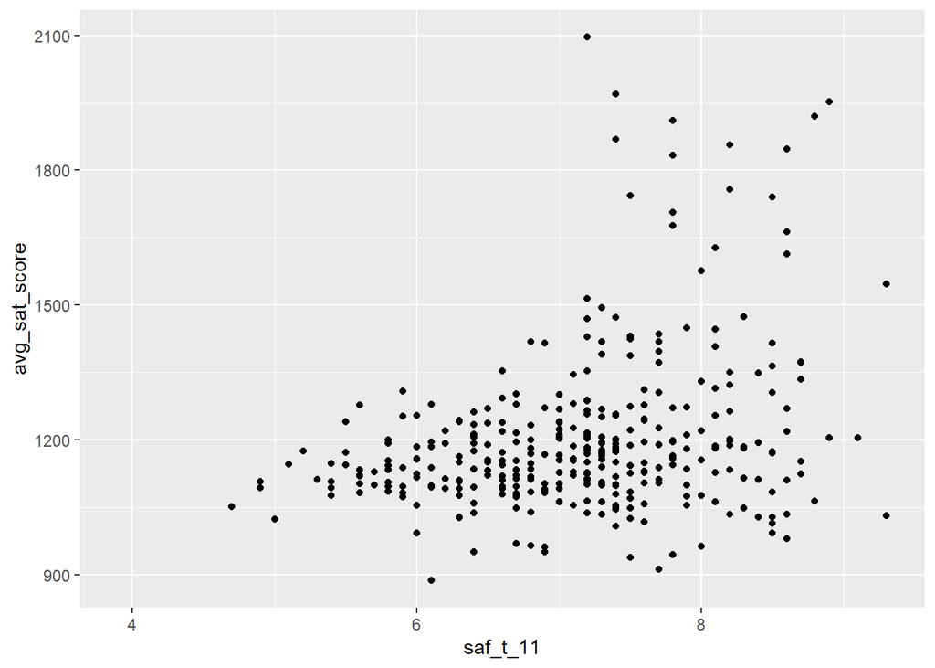

```r
ggplot(data = survey_nychs,
       aes(x = saf_t_11, y = avg_sat_score)) +
       geom_point()
```

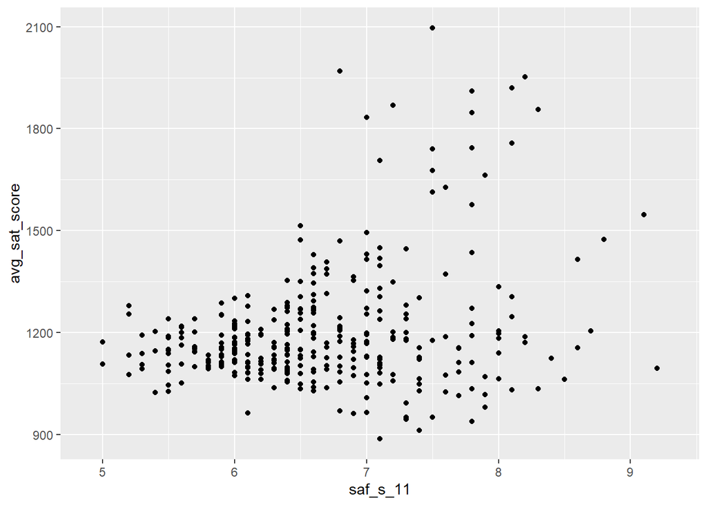

```r
ggplot(data = survey_nychs,
       aes(x = saf_s_11, y = avg_sat_score)) +
  geom_point()
```

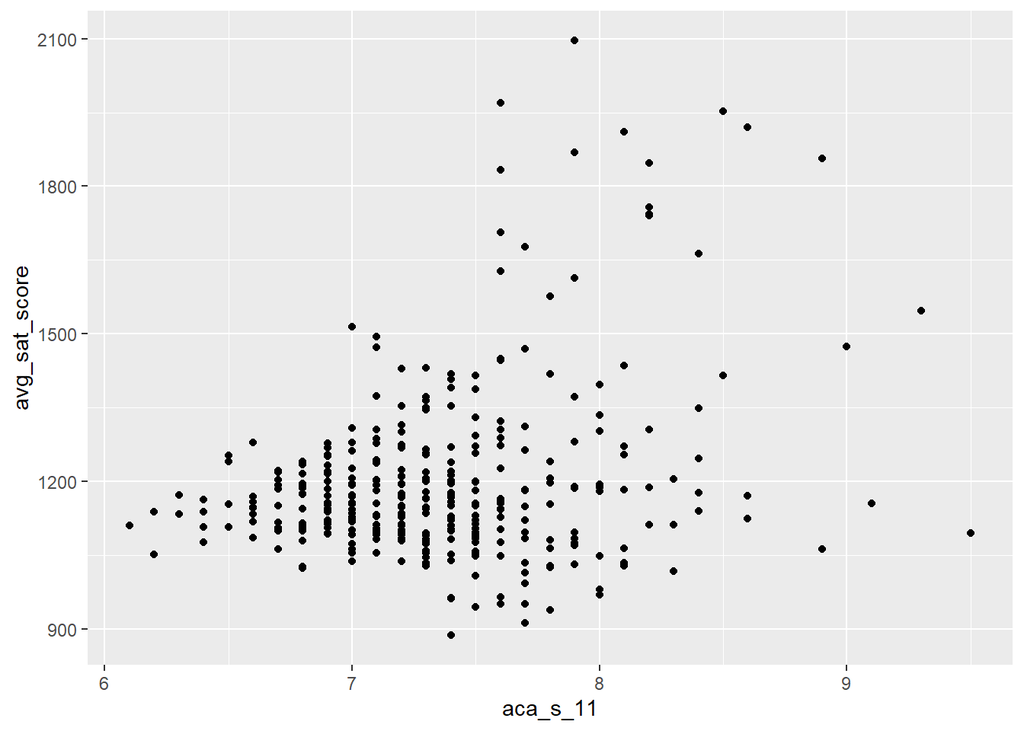

```r
ggplot(data = survey_nychs,
       aes(x = aca_s_11, y = avg_sat_score)) +
  geom_point()
```

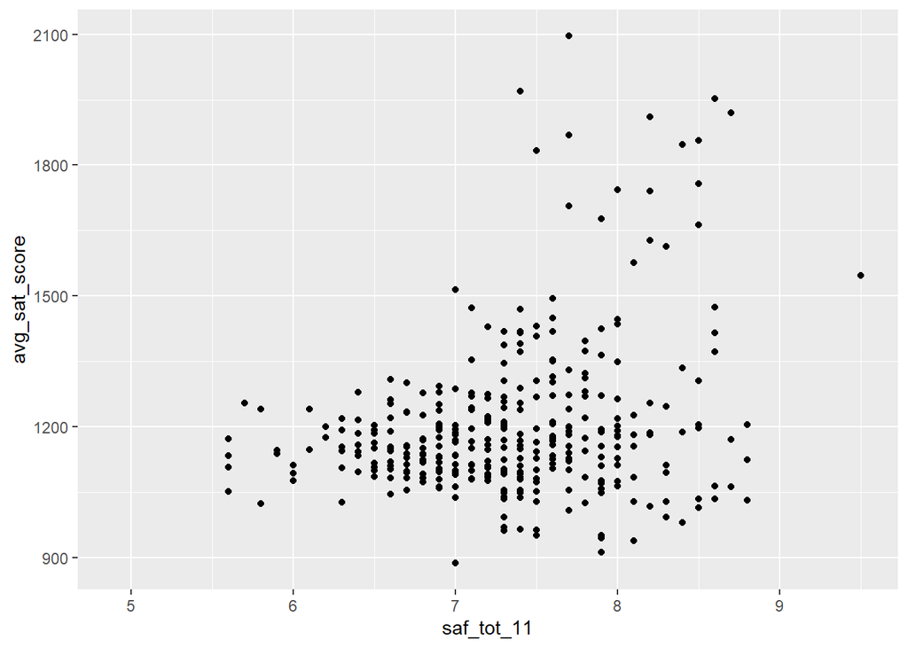

```r
ggplot(data = survey_nychs,
       aes(x = saf_tot_11, y = avg_sat_score)) +
  geom_point()
```

Alternatively, we can iterate using function so we don’t have to write 4 different code chunks

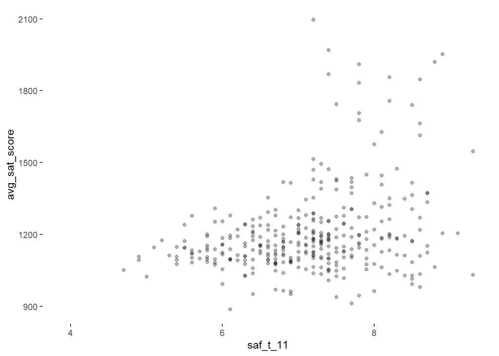

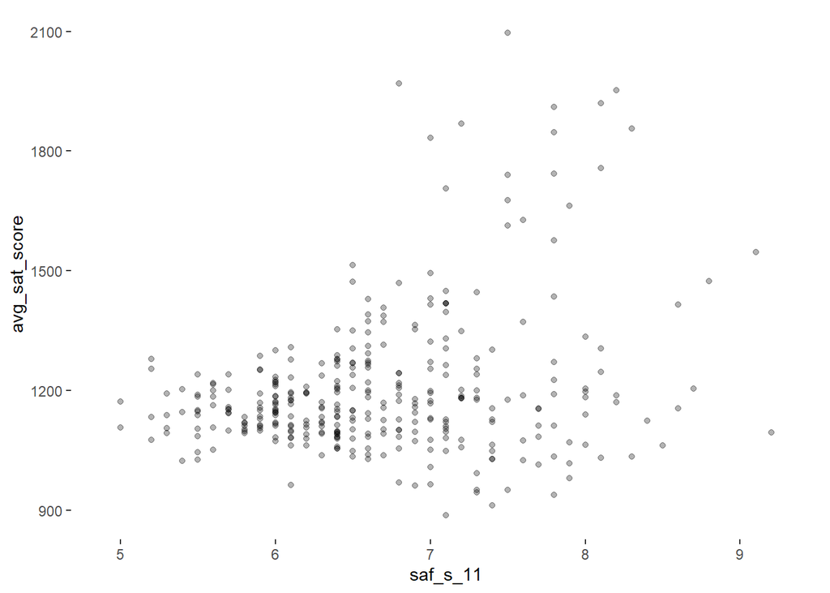

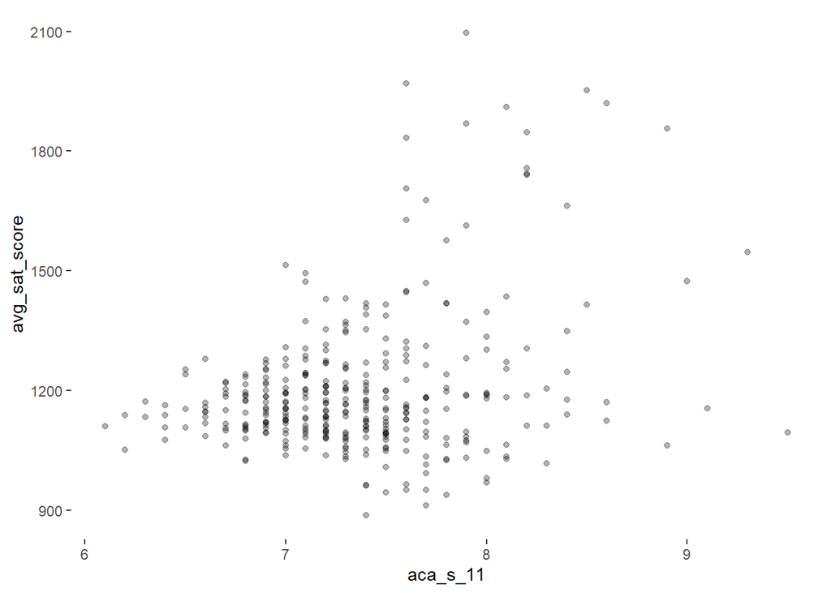

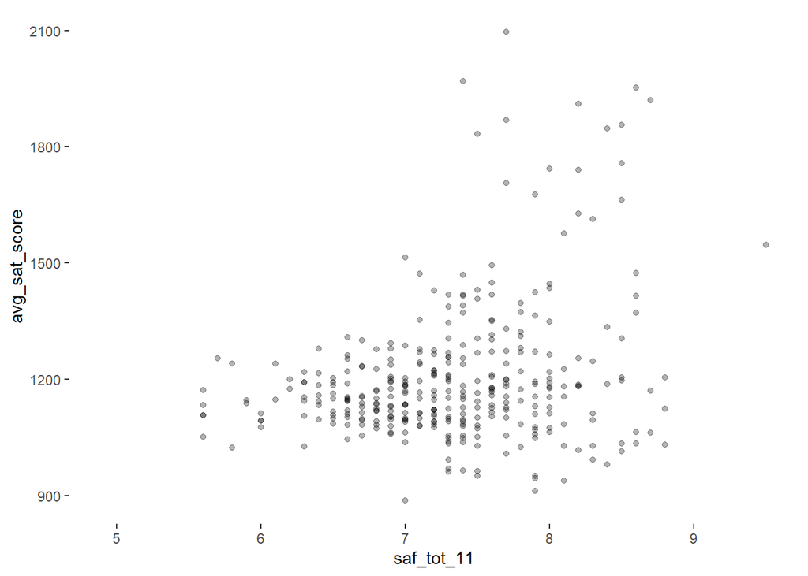

```r
create_scatter <- function(x, y) {
  ggplot(data = survey_nychs) +
    aes_string(x = x, y = y) +
    geom_point(alpha = 0.3) +
    theme(panel.background = element_rect(fill = "white"))
}
x_var <- strong_cors$variable[2:5]
y_var <- "avg_sat_score"

map2(x_var, y_var, create_scatter)
```

```r
print(x_var)
```

```
## [1] "saf_t_11"   "saf_s_11"   "aca_s_11"   "saf_tot_11"
```

The avg_sat_score has a positive relationship with all 4 variables of interest i.e: “saf_t_11”, “saf_s_11”, “aca_s_11”, “saf_tot_11”  
In other words, the sat_score increased the more Safety and Respect score (for teachers) increased. Same case applied to students and all respondent groups. The sat_score increased the more Academic expectations score (for students) increased.

# Reshape the data so it’s more informative

To make it easier to see responses for all metrics by all groups, we’ll reshape the data from wide to long data

```r
survey_nychs_long <- survey_nychs %>%
  pivot_longer(
    cols = c(saf_p_11:aca_tot_11),       #stacks the perception columns(survey questions) together
    names_to = "survey_question",
    values_to = "score"
  )

View(survey_nychs_long)
```

Create 2 new variables from the survey_question column i.e. metric & respondent

```r
survey_nychs_long <- survey_nychs_long %>%
  mutate(
    metric = str_sub(survey_question, 1, 3),       #str_sub() function extracted infor from the survey_question variable
    respondent = str_sub(survey_question, 4, 6)    # start & end characters could have been 5, 5 but there are 2 t's for teacher & total
  )
```

Replace the values in metric & respondent columns with more meaningful names

```r
survey_nychs_long <- survey_nychs_long %>%
  mutate(
    metric = case_when(
      metric == "saf" ~ "safety & respect",
      metric == "com" ~ "communication",
      metric == "eng" ~ "engagement",
      metric == "aca" ~ "academic expectations"
    )
  )
```

```r
survey_nychs_long <- survey_nychs_long %>%
  mutate(
    respondent = case_when(
      respondent == "_p_" ~ "parent",
      respondent == "_t_" ~ "teacher",
      respondent == "_s_" ~ "student",
      respondent == "_to" ~ "total"
    )
  )
```

Alternatively, if_else() can be used in place of case_when(). Restore data in original long format then use if_else()

```r
survey_nychs_long <- survey_nychs %>%
  pivot_longer(
    cols = c(saf_p_11:aca_tot_11),       #stacks the perception columns(survey questions) together
    names_to = "survey_question",
    values_to = "score"
  )
```

```r
survey_nychs_long <- survey_nychs_long %>%
  mutate(
    metric = str_sub(survey_question, 1, 3),       #str_sub() function extracted infor from the survey_question variable
    respondent = str_sub(survey_question, 4, 6)    # start & end characters could have been 5, 5 but there are 2 t's for teacher & total
  )
```

```r
survey_nychs_long <- survey_nychs_long %>%
  mutate(metric = ifelse(metric  == "saf", "safety & respect",
                             ifelse(metric == "com", "communication",
                                    ifelse(metric == "eng", "engagement",
                                           ifelse(metric == "aca", "academic expectations", "NA")))))
```

```r
survey_nychs_long <- survey_nychs_long %>%
  mutate(respondent = ifelse(respondent  == "_p_", "parent",
                                ifelse(respondent == "_t_", "teacher",
                                       ifelse(respondent == "_s_", "student",
                                              ifelse(respondent == "_to", "total", "NA")))))
```

Now it’s manageable to visualize the perceptions

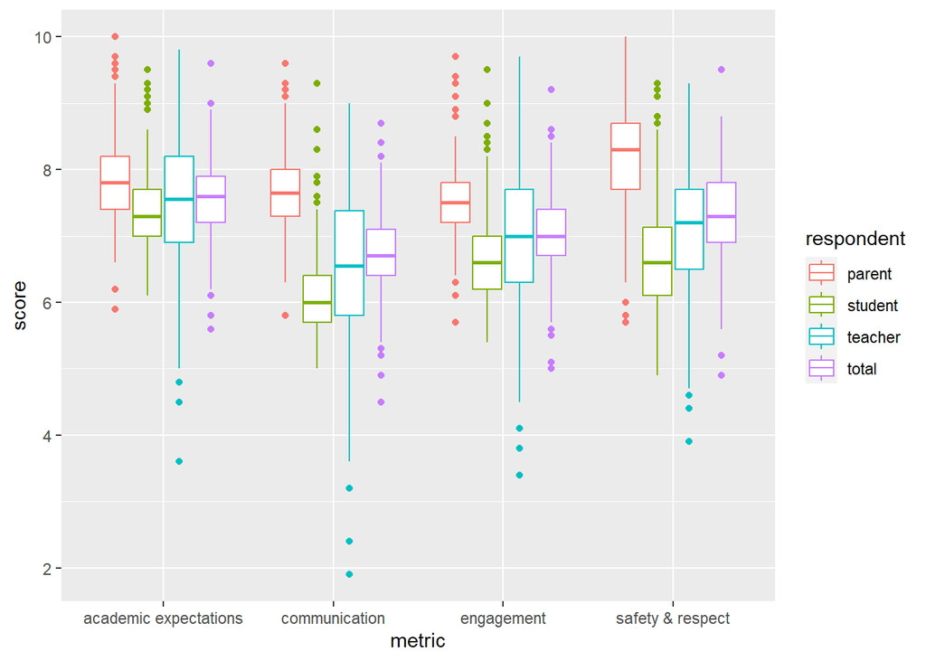

```r
ggplot(data = survey_nychs_long,                    #visualizes all responses
       aes(x = metric, y = score, color = respondent)) +
       geom_boxplot()
```

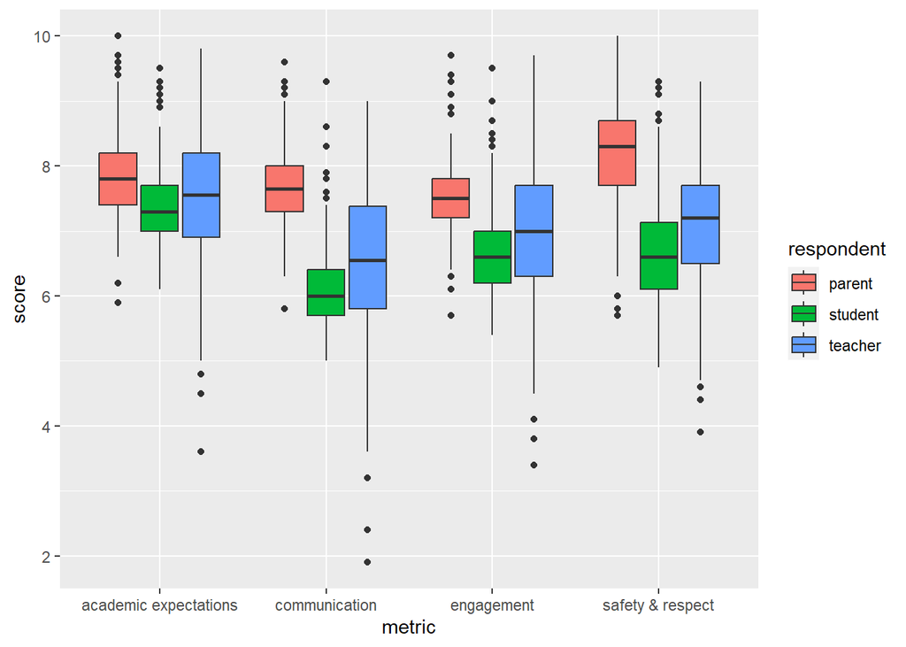

```r
survey_nychs_long %>%
  filter(respondent != "total") %>%
  ggplot(aes(x = metric, y = score, fill = respondent)) +
  geom_boxplot()
```

From the visualization created with code above, it was noted that:

- Scores for teachers were more spread out than those for students and parents
- The larger & smaller scores are equally spread out for all metrics across all groups except safety & respect(among parents) and academic expectations (among students)
- For academic expectations(among students), those that are smaller than medium value are close together.
- For safety & respect(among parents), those that are higher than medium value are closer together.

# Other codes

```r
HS <- survey_combined %>%   #checking unique entries for highschool column
  pull(highschool) %>%
  unique

print(HS)
```

```
## [1] NA  0
```

```r
surveyed <- survey_combined %>%   #checking unique entries for studentssurveyed variable
  pull(studentssurveyed) %>%
  unique

print(surveyed)
```

```
## [1] "Yes" "No"
```

Investigate those which were not surveyed

```r
not_surveyed <- survey_combined %>%
  filter(studentssurveyed == "No")

View(not_surveyed)  #Just 1 obs.
```